# Visium profile of human breast tumour

## Introduction

This vignette walks through a typical workflow on a Visium breast cancer dataset.

## Load Package

```r
library(blisa)
library(SpatialExperiment)
library(ggplot2)
```

## Load Example Data

The example dataset is a small `SpatialExperiment` object (one Visium breast cancer section) hosted as a GitHub Release asset. Download it once and cache locally:

```r
data_url   <- "https://github.com/ChenLaboratory/example_data/releases/download/v1.0.0/spe_visium_bc_s1.rds"
cache_dir  <- tools::R_user_dir("blisa", "cache")
data_file  <- file.path(cache_dir, "spe_visium_bc_s1.rds")

if (!file.exists(data_file)) {
  dir.create(cache_dir, recursive = TRUE, showWarnings = FALSE)
  download.file(data_url, data_file, mode = "wb")
}

spe <- readRDS(data_file)
spe
```

```
#> class: SpatialExperiment
#> dim: 18085 4992
#> metadata(2): um_per_pixel coord_unit
#> assays(1): counts
#> rownames(18085): SAMD11 NOC2L ... MT-ND6 MT-CYB
#> rowData names(3): ID Symbol Type
#> colnames(4992): AACACCTACTATCGAA-1 AACACGTGCATCGCAC-1 ... TGTTGGCCAGACCTAC-1 TGTTGGCCTACACGTG-1
#> colData names(6): in_tissue array_row ... n_genes sample_id
#> reducedDimNames(0):
#> mainExpName: NULL
#> altExpNames(0):
#> spatialCoords names(2) : pxl_col_in_fullres pxl_row_in_fullres
#> imgData names(4): sample_id image_id data scaleFactor
```

## Quality control

For a Visium data, there is no need to run `hexBinCells()` to bin the data. Here we remove spots with less than 3000 total counts.

```r
kp <- Matrix::colSums(counts(spe)) > 3000
table(kp)
```

```
#> kp
#> FALSE  TRUE
#>   580  4412
```

```r
spe <- spe[,kp]
```

## Run BLISA at the LR level

`blisa()` does everything in one call: spatial weights, LR pair filtering against CellChatDB, bivariate Moran’s I per LR pair, and hotspot identification. However, as Visium data is spot-based, there is no cell type annotation by default. Therefore, `blisa()` doesn’t calculate cell-cell interaction scoring as for imaging-based data such as Xenium.

```r
res <- blisa(spe)
```

```
#> Testing 462 LR pairs...
```

```r
res
```

```
#> A blisa object
#>  Level            : lr
#>  LR pairs tested  : 462
#>  Significant      : 462
#>  Bins             : 4412
#>  CCI computed     : FALSE
```

The result is a `blisa` object with five slots:

- `Level` - whether it is LR level or pathway level
- `LR_results` — one row per LR pair, sorted by number of hotspot bins
- `bins` — the hexagonal grid as an `sf` object
- `spatial_weights` — queen and distance-decay weights from `computeSpatialWeights()`
- `CCI_scores` — wide data frame of sender-receiver interaction scores per LR pair

## Run BLISA at the pathway level

To perform pathway level cell-cell communication analyses, we run `blisaPathway()`.

```r
res_pathway <- blisaPathway(res)
res_pathway
```

```
#> A blisa object
#>  Level            : pathway
#>  Pathways tested  : 100
#>  Significant      : 100
#>  Bins             : 4412
#>  CCI computed     : FALSE
```

By default, the pathway level result is the union of each LR pair’s significant hotspot spots, with the minimum (best) p-value per spot. Two alternative methods, Simes’ and Fisher’s methods, are supported to combine p-values of all LR pair’s across hotspot spots.

### Visualization

The `plotLRrank` function visualizes the top interacting pathways across the tissue, ranked by the number of significant hotspot spots.

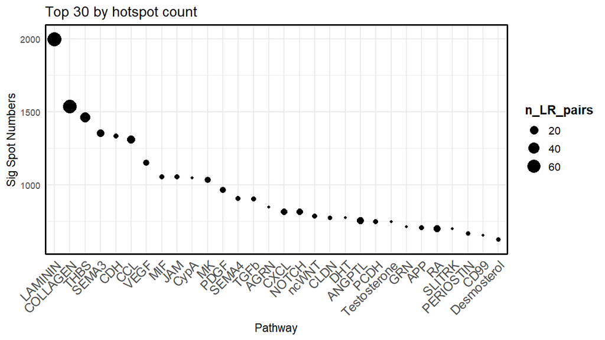

```r
plotLRrank(res_pathway, flip=TRUE)
```

## Spatial Map of Hotspot Bins

For a chosen pathway (here, the top-ranked pathway by default), `plotHotspots` shows which bins are significant hotspots, coloured by p-value. The H&E image can be shown in the backgound using `plotImage` from `scider`.

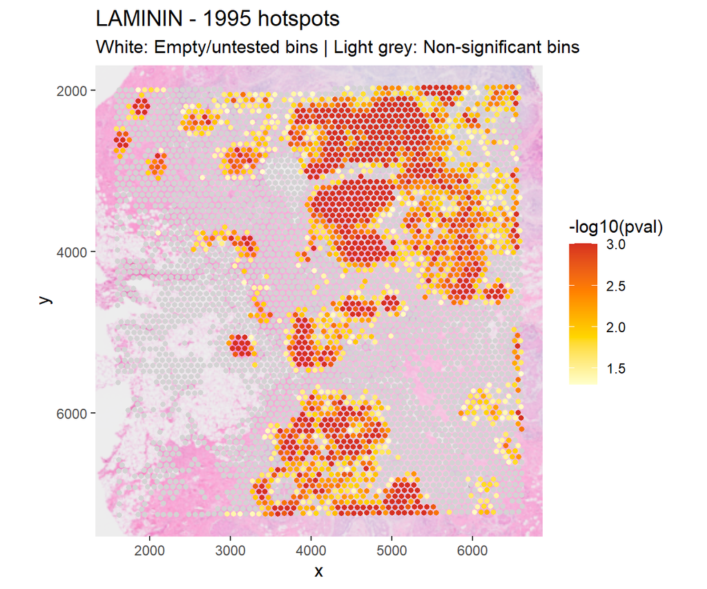

```r
p_img <- scider::plotImage(spe)
plotHotspots(res_pathway, index = 1, background = p_img, size = 1.2)
```